# A summary of the tweets generated at Botany 2022 (#Botany2022)

E.J. Rollinson

## 1. About this document

This document was produced by [Emily J. Rollinson](http://rollinsonecology.com) ([@ejrollinson](https://twitter.com/ejrollinson) on Twitter).

The code generating this document was originally developed by [Francois Michonneau](https://github.com/fmichonneau) ([@fmic_](https://twitter.com/fmic_) on Twitter) for the 2015 Evolution meeting and can be found [here](https://github.com/fmichonneau/evol2015-tweets).

I originally adapted this code for the 2015 Ecological Society of America meeting (#ESA100) in Baltimore, MD, and have since reproduced it for [a series of ESA and Botany meetings](https://erollinson.github.io/). I modified it in 2020 to use the rtweet package instead of twitteR to aggregate tweets, updated the code used to generate the wordcloud, and modified the formatting of the plots. In 2021, I updated the code to embed top tweets using tweetrmd. A new section was added in 2022 following [this suggestion](https://twitter.com/AzKlymiuk/status/1553464116831928320) from [Az Klymiuk](https://twitter.com/AzKlymiuk).

Tweets using the hashtag #Botany2022 were aggregated from Twitter using the R package [rtweet](https://cran.r-project.org/web/packages/rtweet/index.html) and the Twitter API. The summary statistics are static as of 09:00 AM EDT 7/28/2022. Additional tweets, retweets, and likes after that point are not included in the summary, although embedded tweets are “live” and up-to-date.

This document was generated using RMarkdown, and the source is [available on GitHub](https://github.com/erollinson/erollinson.github.io).

This document (and associated code) is released under a CC0 license.

## 2. Basic summary

Of the 5426 tweets tagged #Botany2022 between 2022-07-24 and 2022-07-28:

| Description | n |
| --- | --- |
| Total of original tweets (no retweets): | 1377 |
| Number of users who tweeted (including retweeting): | 1173 |
| Number of users who tweeted (no retweets): | 318 |

## 3. Building a Botany Twitter community

The figures in this section were made following [this suggestion](https://twitter.com/AzKlymiuk/status/1553464116831928320) from [Az Klymiuk](https://twitter.com/AzKlymiuk). Thank you!

### Number of users retweeted

This figure summarizes breadth of retweeting among users of the #Botany2022 hashtag during the conference - how many different users did a given account retweet?

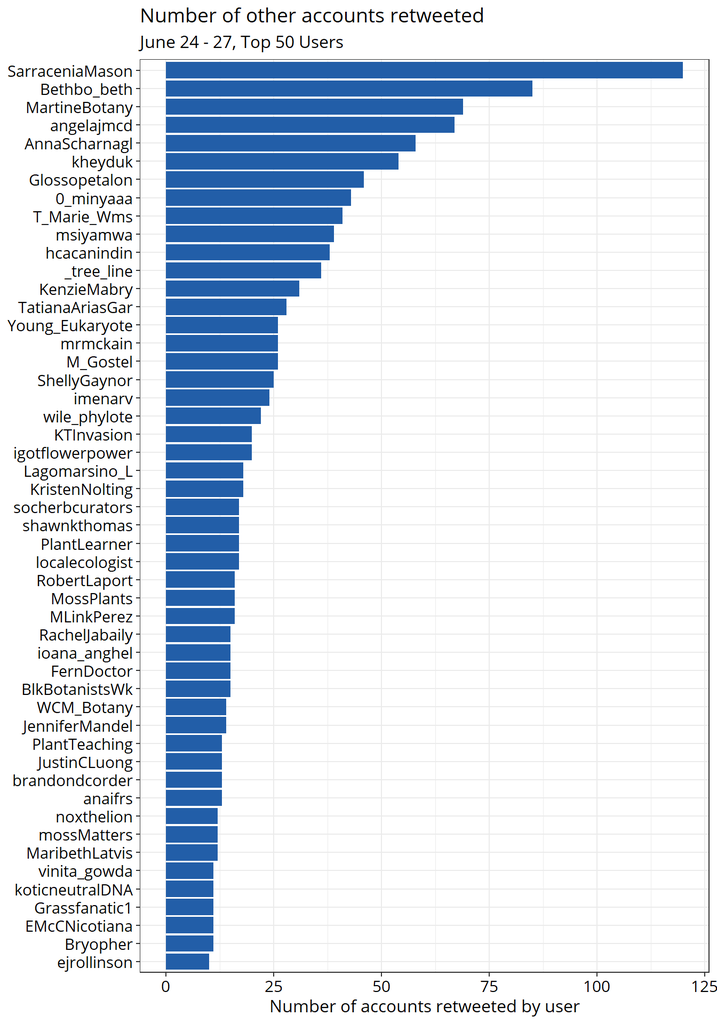

### Number of retweets of smaller accounts

‘Smaller’ accounts is defined here as accounts with fewer than 250 followers. (This is approximately 25% of accounts using the hashtag.) Such smaller accounts collectively tweeted 158 of the 1377 original tweets using the #Botany2022 hashtag. The counts here are number of tweets, rather than number of accounts - each RT of a tweet from a small account is tallied here.

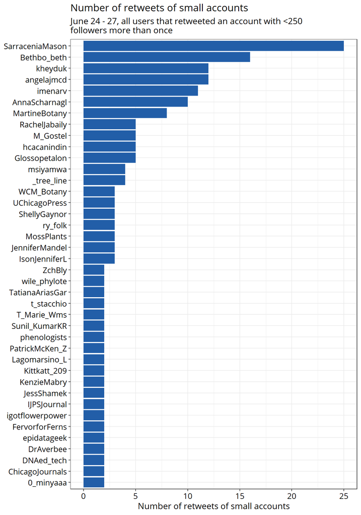

### Number of small accounts tagged

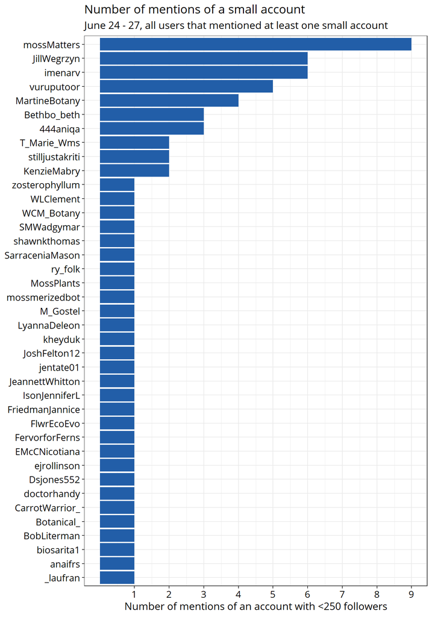

## 4. Number of tweets

### Only for original tweets (retweets excluded)

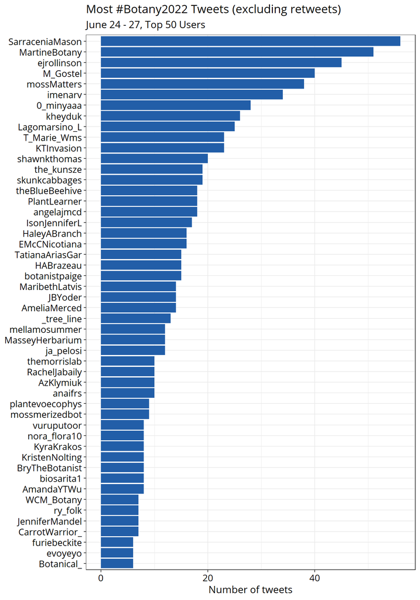

### All generated tweets (including retweets)

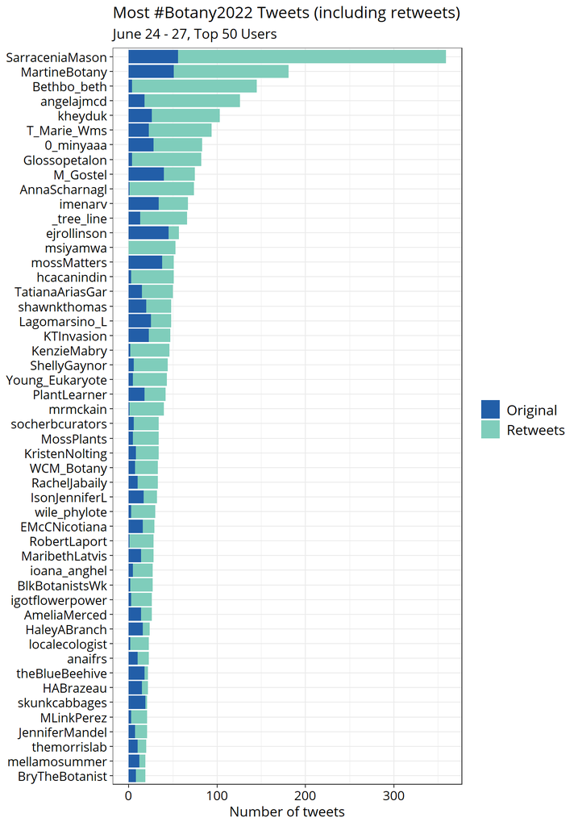

## 5. The 5 most liked tweets

> I'm very happy to be able to participate virtually in [#Botany2022](https://twitter.com/hashtag/Botany2022?src=hash&ref_src=twsrc%5Etfw) !!!  
> Check out my talk tomorrow on these beautiful plants [#Tropaeolum](https://twitter.com/hashtag/Tropaeolum?src=hash&ref_src=twsrc%5Etfw)https://t.co/EwIRjfJxXt [pic.twitter.com/mc58Z7jsRG](https://t.co/mc58Z7jsRG)

> — Sebastián Martínez-Salazar (@SebastianMarSa) [July 25, 2022](https://twitter.com/SebastianMarSa/status/1551364255085170688?ref_src=twsrc%5Etfw)

> Sad to be missing [#Botany2022](https://twitter.com/hashtag/Botany2022?src=hash&ref_src=twsrc%5Etfw) (currently moving), but excited to work with amazing scientists at [@okstate](https://twitter.com/okstate?ref_src=twsrc%5Etfw)! I’ll be looking for students to join me in Fall 2023! Email or DM me if interested in plant morph, bulbs, and/or phylogenomics! Or reach out to just chat plants! [#NewPI](https://twitter.com/hashtag/NewPI?src=hash&ref_src=twsrc%5Etfw) [pic.twitter.com/oyyQr6Mh9N](https://t.co/oyyQr6Mh9N)

> — Cody Coyotee Howard (@wile_phylote) [July 25, 2022](https://twitter.com/wile_phylote/status/1551590833815691264?ref_src=twsrc%5Etfw)

> Just superb. [#botany2022](https://twitter.com/hashtag/botany2022?src=hash&ref_src=twsrc%5Etfw) [pic.twitter.com/VBZWTPnDuJ](https://t.co/VBZWTPnDuJ)

> — Harpo Faust (@softcorebotany) [July 26, 2022](https://twitter.com/softcorebotany/status/1552070581155049472?ref_src=twsrc%5Etfw)

> My [#botany2022](https://twitter.com/hashtag/botany2022?src=hash&ref_src=twsrc%5Etfw) poster is up!! Make sure to swing by poster 103 tomorrow evening to hear about the [@Shutterbeez](https://twitter.com/Shutterbeez?ref_src=twsrc%5Etfw) project [pic.twitter.com/QTCx6fPRbQ](https://t.co/QTCx6fPRbQ)

> — Josh Felton (@JoshFelton12) [July 24, 2022](https://twitter.com/JoshFelton12/status/1551330721876156416?ref_src=twsrc%5Etfw)

> finally made it! [#Botany2022](https://twitter.com/hashtag/Botany2022?src=hash&ref_src=twsrc%5Etfw) [pic.twitter.com/Cn7ZptIynW](https://t.co/Cn7ZptIynW)

> — Maribeth Latvis (@MaribethLatvis) [July 25, 2022](https://twitter.com/MaribethLatvis/status/1551445340842102785?ref_src=twsrc%5Etfw)

## 6. The 5 most retweeted tweets

> Sad to be missing [#Botany2022](https://twitter.com/hashtag/Botany2022?src=hash&ref_src=twsrc%5Etfw) (currently moving), but excited to work with amazing scientists at [@okstate](https://twitter.com/okstate?ref_src=twsrc%5Etfw)! I’ll be looking for students to join me in Fall 2023! Email or DM me if interested in plant morph, bulbs, and/or phylogenomics! Or reach out to just chat plants! [#NewPI](https://twitter.com/hashtag/NewPI?src=hash&ref_src=twsrc%5Etfw) [pic.twitter.com/oyyQr6Mh9N](https://t.co/oyyQr6Mh9N)

> — Cody Coyotee Howard (@wile_phylote) [July 25, 2022](https://twitter.com/wile_phylote/status/1551590833815691264?ref_src=twsrc%5Etfw)

> My Lab is recruiting a [#phd](https://twitter.com/hashtag/phd?src=hash&ref_src=twsrc%5Etfw) student for 2023. Includes 3 years of funding for fieldwork, evolutionary analysis of [#moss](https://twitter.com/hashtag/moss?src=hash&ref_src=twsrc%5Etfw) [#anatomy](https://twitter.com/hashtag/anatomy?src=hash&ref_src=twsrc%5Etfw), experiments on resource transport, & natural history [#collections](https://twitter.com/hashtag/collections?src=hash&ref_src=twsrc%5Etfw). https://t.co/0WKkz48TsQ Please RT & thanks! [#gradschool](https://twitter.com/hashtag/gradschool?src=hash&ref_src=twsrc%5Etfw) [#Botany2022](https://twitter.com/hashtag/Botany2022?src=hash&ref_src=twsrc%5Etfw) [@botanical_](https://twitter.com/Botanical_?ref_src=twsrc%5Etfw) [pic.twitter.com/piTr27y711](https://t.co/piTr27y711)

> — Jessica Budke PhD (@MossPlants) [July 24, 2022](https://twitter.com/MossPlants/status/1551338248542175232?ref_src=twsrc%5Etfw)

> Hey [#Botany2022](https://twitter.com/hashtag/Botany2022?src=hash&ref_src=twsrc%5Etfw), my graduate institution is looking for an Herbarium Curator! Master's degree level with two years herbarium experience... See more here: https://t.co/BhKpIyUMuj

> — Dr. Melanie Link-Perez 🏳️‍🌈🌿 (@MLinkPerez) [July 27, 2022](https://twitter.com/MLinkPerez/status/1552156044142395392?ref_src=twsrc%5Etfw)

> A talk made me speechless. This is a talk worth downloading in your PC, watch many times, and show it to everyone you know. What a phenomenal speaker, teacher, educator, scientist, communicator, and leader, [@T_Marie_Wms](https://twitter.com/T_Marie_Wms?ref_src=twsrc%5Etfw). [#BlackBotanistsWeek](https://twitter.com/hashtag/BlackBotanistsWeek?src=hash&ref_src=twsrc%5Etfw) [#Botany2022](https://twitter.com/hashtag/Botany2022?src=hash&ref_src=twsrc%5Etfw) [pic.twitter.com/py6dUzOrJp](https://t.co/py6dUzOrJp)

> — 闵娅 (Min Ya | Minya), PhD (@0_minyaaa) [July 26, 2022](https://twitter.com/0_minyaaa/status/1551730920540946432?ref_src=twsrc%5Etfw)

> [#Botany2022](https://twitter.com/hashtag/Botany2022?src=hash&ref_src=twsrc%5Etfw) contributions by the [@SpechtLab](https://twitter.com/SpechtLab?ref_src=twsrc%5Etfw) [pic.twitter.com/2bkIhQ9bra](https://t.co/2bkIhQ9bra)

> — Dr. Chelsea D. Specht (@plantevomorph) [July 25, 2022](https://twitter.com/plantevomorph/status/1551616223124660225?ref_src=twsrc%5Etfw)

## 7. Word cloud

The top 100 words among the original tweets, excluding retweets, hashtags, mentions, URLs, and common English words (“the’,”&“, etc.).

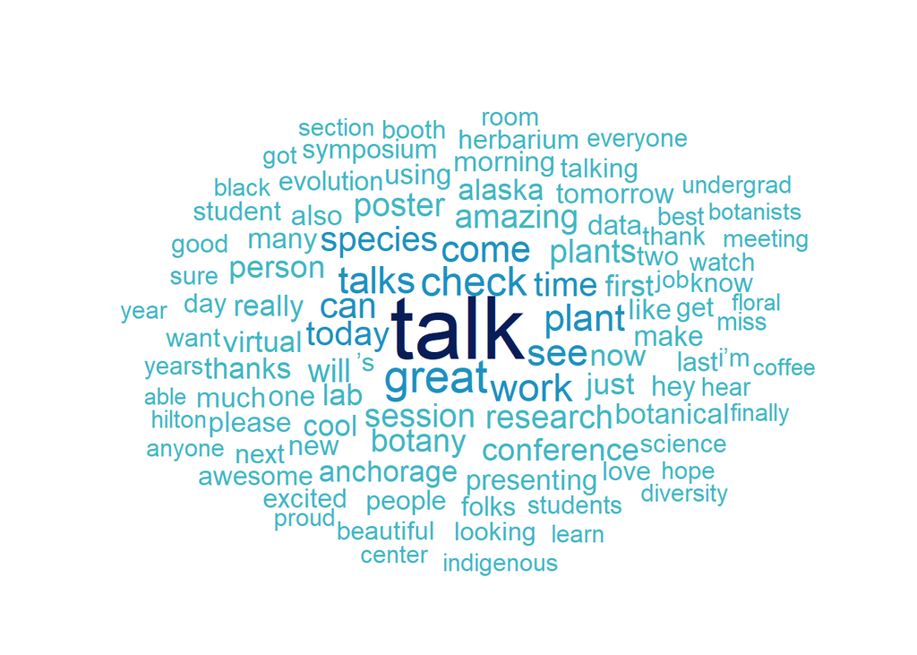

## 8. Data tables

Data tables for the figures above.

### Most accounts retweeted

| screen_name | users_rtd |
| --- | --- |
| SarraceniaMason | 120 |
| Bethbo_beth | 85 |
| MartineBotany | 69 |
| angelajmcd | 67 |
| AnnaScharnagl | 58 |
| kheyduk | 54 |
| Glossopetalon | 46 |
| 0_minyaaa | 43 |
| T_Marie_Wms | 41 |
| msiyamwa | 39 |

[output cut: 40 more lines]

### Number of retweets of small accounts

| screen_name | rts_ct |
| --- | --- |
| SarraceniaMason | 25 |
| Bethbo_beth | 16 |
| angelajmcd | 12 |
| kheyduk | 12 |
| imenarv | 11 |
| AnnaScharnagl | 10 |
| MartineBotany | 8 |
| Glossopetalon | 5 |
| hcacanindin | 5 |
| M_Gostel | 5 |

[output cut: 161 more lines]

### Number of mentions of small accounts

| screen_name | ntags |
| --- | --- |
| mossMatters | 9 |
| imenarv | 6 |
| JillWegrzyn | 6 |
| vuruputoor | 5 |
| MartineBotany | 4 |
| 444aniqa | 3 |
| Bethbo_beth | 3 |
| KenzieMabry | 2 |
| stilljustakriti | 2 |
| T_Marie_Wms | 2 |

[output cut: 29 more lines]

### Top tweeters, excluding retweets

| screen_name | Original |
| --- | --- |
| SarraceniaMason | 56 |
| MartineBotany | 51 |
| ejrollinson | 45 |
| M_Gostel | 40 |
| mossMatters | 38 |
| imenarv | 34 |
| 0_minyaaa | 28 |
| kheyduk | 26 |
| Lagomarsino_L | 25 |
| KTInvasion | 23 |

[output cut: 40 more lines]

### Top tweeters, including retweets

| screen_name | total_tweets | Original | Retweets |
| --- | --- | --- | --- |
| SarraceniaMason | 359 | 56 | 303 |
| MartineBotany | 181 | 51 | 130 |
| Bethbo_beth | 145 | 4 | 141 |
| angelajmcd | 126 | 18 | 108 |
| kheyduk | 103 | 26 | 77 |
| T_Marie_Wms | 94 | 23 | 71 |
| 0_minyaaa | 83 | 28 | 55 |
| Glossopetalon | 82 | 4 | 78 |
| M_Gostel | 75 | 40 | 35 |
| AnnaScharnagl | 74 | 1 | 73 |

[output cut: 40 more lines]

### Corpus (Word cloud)

| word | freq |
| --- | --- |
| talk | 301 |
| great | 116 |
| check | 96 |
| work | 87 |
| talks | 84 |
| see | 79 |
| plant | 79 |
| come | 76 |
| can | 73 |
| species | 66 |

[output cut: 5214 more lines]

To the extent possible under law, [Emily J. Rollinson](https://github.com/erollinson/erollinson.github.io) has waived all copyright and related or neighboring rights to Summary of tweets at Botany 2022. This work is published from: United States.